# Temporal and Regional Analysis of Earthquake Activity in Turkey (1975–2023)

Welcome to our project page.

Here, you’ll find updates and insights from our ongoing exploration of earthquake patterns in Turkey.

# 1. Project Overview and Scope

Earthquakes are one of the most important natural hazards in Turkey, a country that located on several active fault lines — especially the North Anatolian Fault Zone. Understanding when and where earthquakes happen is essential for planning, risk reduction, and disaster preparation.

The main question of this research is:

> **“How did earthquake frequency and magnitude change in Turkey over time, and which regions show the most consistent seismic activity?”**

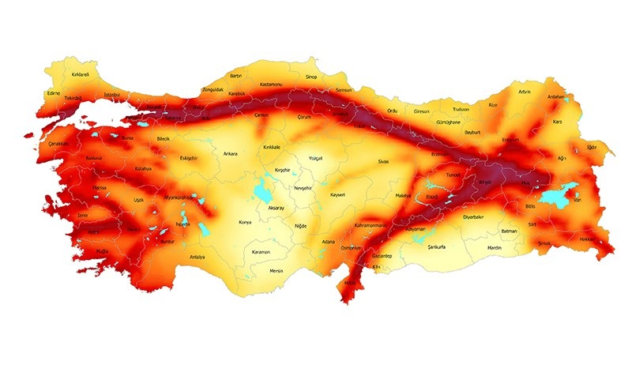

To answer this question, the project sets the following objectives:

- **Temporal Analysis**: Track annual or seasonal shifts in earthquake frequency and intensity.
- **Spatial Mapping**: Visualize the geographic clustering of earthquakes to identify high-risk zones.
- **Magnitude Patterns**: Investigate the distribution of magnitudes and how often stronger quakes occur.
- **Risk Identification**: Identify areas of Turkey that exhibit consistently high seismic activity and may require closer monitoring or mitigation efforts.
- **Visualization**: Produce clear and informative visualizations, including histograms, time series plots, and density maps, to support interpretations.

All analyses are performed in **R**, and the project is compiled and shared through a **Quarto-powered GitHub page**, making it fully transparent and reproducible. The final product is intended to be both informative and accessible to audiences interested in Turkey’s seismic landscape—whether in research, policy, or planning.

# 2. Data

## 2.1 Data Source

The dataset was downloaded in `.csv` format and contains information such as:

- **Date and Time** of the earthquake
- **Magnitude**
- **Depth (in kilometers)**
- **Latitude and Longitude**
- **Place** (a descriptive region name)

After downloading, the data was imported into R for further exploration and preprocessing.

## 2.2 General Information About Data

Here’s a brief overview of the variables:

- `time`: Timestamp of the earthquake (UTC), including date and hour
- `latitude` & `longitude`: Geographic location of the event
- `depth`: Depth below the surface in kilometers
- `mag`: Magnitude on the Richter scale
- `place`: Descriptive label provided by USGS, such as nearby city or region

Overall, The structure of the dataset is tidy and consistent, which makes it easier to analyze without extensive restructuring. Thanks to its clean structure, the dataset served as an effective and convenient entry point for our analysis.

## 2.3 Reason of Choice

There are several reasons why we chose this specific dataset:

- First and foremost, earthquakes have always been a critical topic in Turkey, especially following the devastating seismic events in 1999 and more recently in 2023. Understanding patterns in historical data can offer valuable insights into risk mitigation.
- Second, the dataset is both **rich** and **clean**, and doesn’t require extensive preprocessing to begin analysis. It offers a long temporal range (1975–2023), which makes it ideal for trend detection.
- Lastly, We wanted a dataset that is directly relevant to public safety and urban planning in Turkey. The output of this study could contribute to further academic or policy-oriented discussions about seismic preparedness.

## 2.4 Preprocessing

After importing the CSV file into R, several preprocessing steps were performed to prepare the dataset for analysis:

The cleaned dataset was saved in `.RData` format for reproducibility and faster processing in future sessions.

```r
eq_data <- read.csv("turkey_earthquake_data.csv")
eq_data$DateTime <- as.POSIXct(eq_data$time, format="%Y-%m-%dT%H:%M:%OSZ", tz="UTC")
eq_data <- subset(eq_data, mag >= 3.0)
eq_data$year <- format(eq_data$DateTime, "%Y")
eq_data <- eq_data[ , !(names(eq_data) %in% c("magType", "nst", "gap", "dmin", "rms",
                                              "net", "id", "updated", "type",
                                              "horizontalError", "depthError",
                                              "magError", "magNst", "status"))]
save(eq_data, file="eq_data.RData")
```

### Sample of the Cleaned Dataset

The table below presents the first few rows of the cleaned earthquake dataset used in this study. After filtering out earthquakes below magnitude 3.0 and removing irrelevant columns, the dataset now includes key attributes such as date, location, magnitude, and depth. This refined structure allows for a more focused analysis of significant seismic activity in Turkey from 1975 to 2023.

```r
library(knitr)

# İlk 10 satırı daha düzgün biçimli tablo olarak göster
kable(head(eq_data, 10), caption = "Table 1: Sample of Pre-processed Earthquake Data")
```

Table 1: Sample of Pre-processed Earthquake Data

| time | latitude | longitude | depth | mag | place | locationSource | magSource | DateTime | year |
| --- | --- | --- | --- | --- | --- | --- | --- | --- | --- |
| 1975-04-23T01:08:08.500Z | 40.450 | 26.076 | 20 | 4.3 | 30 km S of Enez, Turkey | us | us | 1975-04-23 01:08:08 | 1975 |
| 1975-04-30T04:28:56.900Z | 36.184 | 30.772 | 56 | 5.6 | 41 km SSE of Tekirova, Turkey | us | us | 1975-04-30 04:28:56 | 1975 |
| 1975-05-02T05:03:19.300Z | 36.221 | 30.612 | 43 | 3.9 | 30 km ESE of Beykonak, Turkey | us | us | 1975-05-02 05:03:19 | 1975 |
| 1975-05-07T17:59:15.800Z | 40.370 | 26.092 | 33 | 3.9 | 24 km NE of Gökçeada, Turkey | us | ath | 1975-05-07 17:59:15 | 1975 |
| 1975-05-30T05:13:45.100Z | 39.118 | 27.747 | 10 | 3.9 | 6 km E of K?rka?aç, Turkey | us | us | 1975-05-30 05:13:45 | 1975 |
| 1975-05-30T14:22:40.800Z | 38.732 | 27.620 | 9 | 4.2 | 4 km E of Saruhanl?, Turkey | us | ath | 1975-05-30 14:22:40 | 1975 |
| 1975-05-31T05:36:52.900Z | 36.162 | 29.015 | 42 | 4.0 | 37 km WSW of Kalkan, Turkey | us | us | 1975-05-31 05:36:52 | 1975 |
| 1975-05-31T12:41:23.900Z | 36.642 | 28.131 | 19 | 4.0 | 19 km SSW of ?çmeler, Turkey | us | us | 1975-05-31 12:41:23 | 1975 |
| 1975-06-02T03:19:07.200Z | 36.652 | 26.590 | 25 | 4.5 | 24 km ENE of Astypálaia, Greece | us | us | 1975-06-02 03:19:07 | 1975 |
| 1975-06-04T02:55:37.000Z | 40.857 | 31.513 | 68 | 3.8 | 15 km NNW of Bolu, Turkey | us | us | 1975-06-04 02:55:37 | 1975 |

# 3. Analysis

In this part of the project, we took a closer look at Turkey’s earthquake data to spot trends and patterns in seismic activity. We started by getting familiar with the dataset—checking its overall structure, looking at the spread of magnitudes and depths, and making sure the data was clean enough to work with. There were a few missing values, but most of them wasn’t a big issue and were handled early on.

All the analysis was done in R, using tools that are great for working with spatial data and making visuals. Overall, the findings give a useful starting point for deeper studies and could help people working in planning, safety, or research to better understand Turkey’s earthquake patterns.

## 3.1 Exploratory Data Analysis

In this section, we will conduct an exploratory analysis of the earthquake data to understand its basic structure and identify potential patterns or issues.

### 3.1.1 Overview of the Dataset

- **DateTime**: The exact date and time of each earthquake (in UTC).
- **latitude**: The north–south coordinate of the event.
- **longitude**: The east–west coordinate of the event.
- **depth**: The depth of the earthquake’s focus, in kilometers.
- **mag**: The magnitude of the earthquake, based on the Richter scale.
- **place**: A textual description of the location, such as nearby towns or provinces.
- **year**: Extracted from the date, useful for time-series grouping.

The dataset is structured in a tidy format with no missing values in the key analytical fields.

```r
sum(is.na(eq_data))
```

```
[1] 0
```

## 3.2 Visualization and Analysis

Understanding the distributions of key variables gives insight into the data’s characteristics and helps identify any anomalies or patterns.

**Earthquake Magnitude Distribution**

The magnitude of earthquakes is fundamental to assessing seismic risk. This histogram shows how often different magnitude values occur in the dataset.

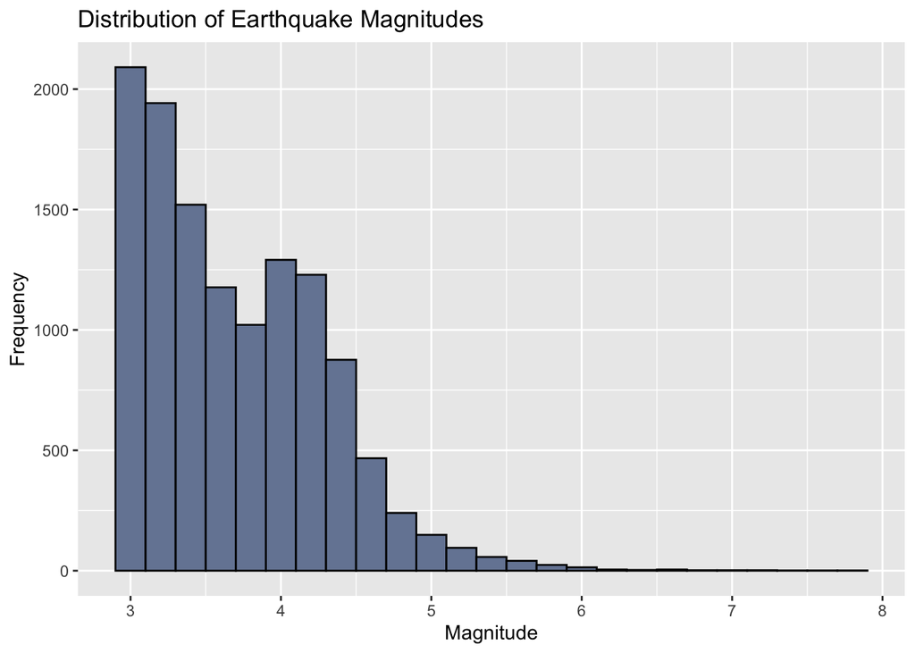

```r
library(ggplot2)
ggplot(eq_data, aes(x = mag)) +
  geom_histogram(binwidth = 0.2, fill = "#7686A3", color = "black") +
  labs(title = "Distribution of Earthquake Magnitudes",
       x = "Magnitude", y = "Frequency")
```

**Earthquake Depth Distribution**

Depth indicates how deep beneath the surface an earthquake originates. This histogram helps us understand the typical depth range of earthquakes in Turkey.

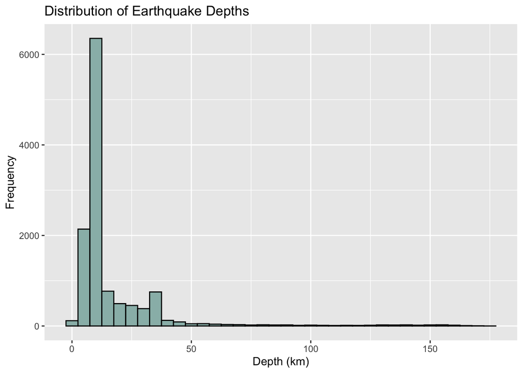

```r
ggplot(eq_data, aes(x = depth)) +
  geom_histogram(binwidth = 5, fill = "#99BAB6", color = "black") +
  labs(title = "Distribution of Earthquake Depths",
       x = "Depth (km)", y = "Frequency")
```

**Earthquake Frequency Over Time**

Next, we analyze how earthquake occurrences vary over the years. This temporal view is crucial for detecting trends or changes in seismic activity.

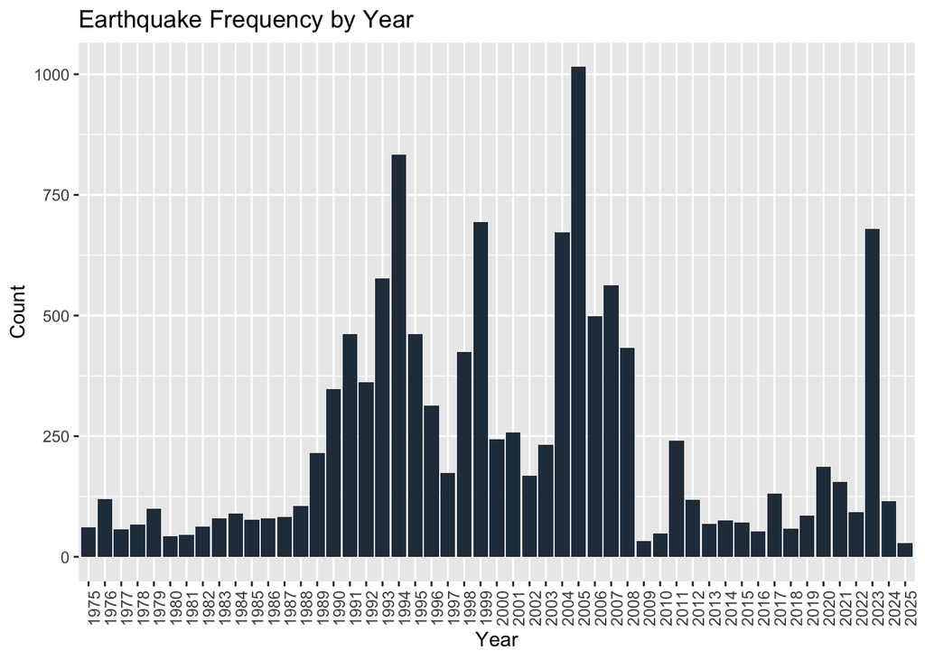

```r
eq_data$year <- format(as.Date(eq_data$DateTime), "%Y")
earthquakes_per_year <- table(eq_data$year)

ggplot(data.frame(year = names(earthquakes_per_year), count = as.numeric(earthquakes_per_year)),
       aes(x = year, y = count)) +
  geom_bar(stat = "identity", fill = "#27394A") +
  theme(axis.text.x = element_text(angle = 90)) +
  labs(title = "Earthquake Frequency by Year",
       x = "Year", y = "Count")
```

**Spatial Distribution of Earthquakes**

Mapping earthquake epicenters provides spatial insights and helps identify regions of concentrated seismic activity.

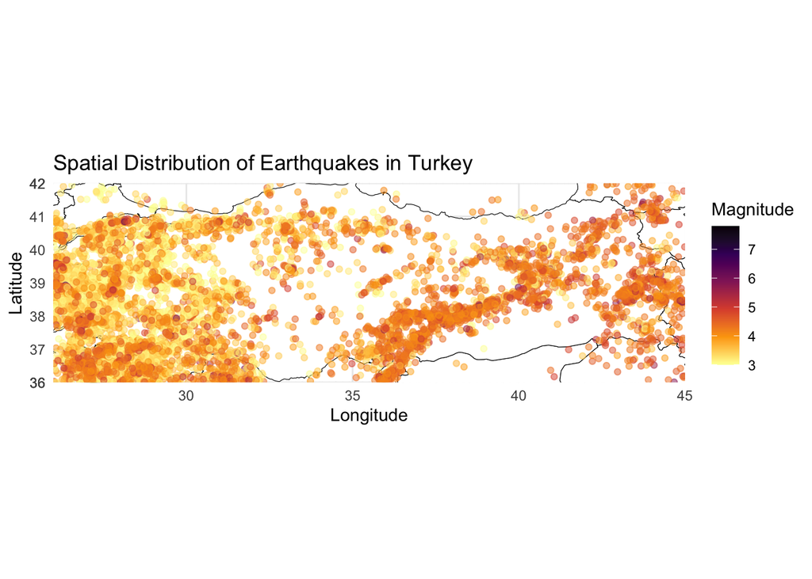

```r
library(ggplot2)
library(sf)
turkey_shapefile <- st_read("/Users/akbulut/Documents/GitHub/emu660-spring2025-edagrlk/turkey.shp")
ggplot() +
  geom_sf(data = turkey_shapefile, fill = "white", color = "black") +
  geom_point(data = eq_data, aes(x = longitude, y = latitude, color = mag), alpha = 0.5) +
  scale_color_viridis_c(option = "inferno", direction = -1) +
  coord_sf(xlim = c(26, 45), ylim = c(36, 42), expand = FALSE) +
  labs(title = "Spatial Distribution of Earthquakes in Turkey",
       x = "Longitude", y = "Latitude", color = "Magnitude") +
  theme_minimal()
```

### 3.2.1. Spatial Distribution of Earthquakes in Turkey: Top 10 Years by Frequency

This series of maps shows where earthquakes occurred during the ten years when Turkey experienced the highest levels of seismic activity. By focusing on these especially active years, we can get a better sense of how earthquake epicenters were spread out across different parts of the country during times when the ground was particularly restless.

On each map, earthquakes are colored based on their magnitude, which makes it easier to pick out the stronger ones at a glance. To make sure significant events aren’t overlooked, we also displayed earthquakes over magnitude 5 as larger points that stand out more clearly.

It’s important to keep in mind that the high number of earthquakes in some of these years might be partly due to swarms of aftershocks following major events. These aftershocks, while smaller, still contribute to the overall seismic activity and can create noticeable clusters in certain regions.

These maps help us spot patterns—like which areas tend to shake more during active periods. Recognizing these hotspots is a key step for understanding risk and making smarter decisions about safety and planning in those regions.

```
### Earthquake Distribution for Year: 2005
```

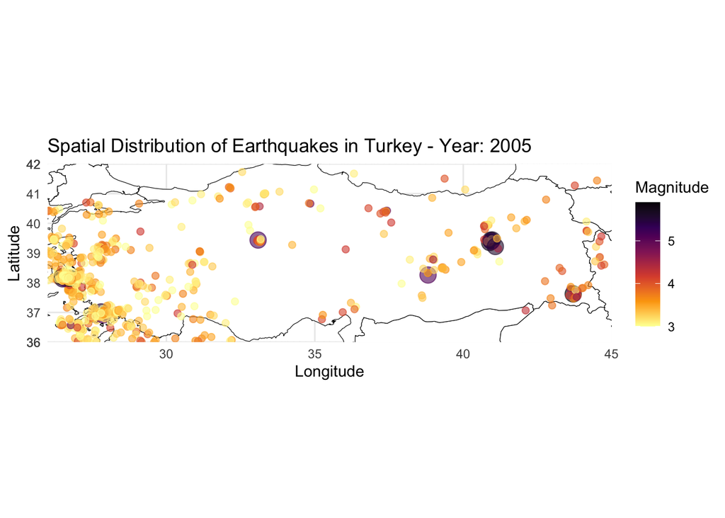

```
### Earthquake Distribution for Year: 1994
```

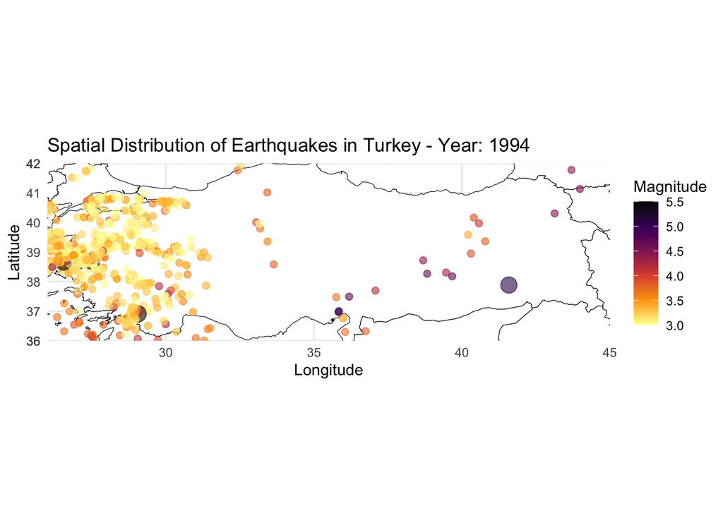

```
### Earthquake Distribution for Year: 1999
```

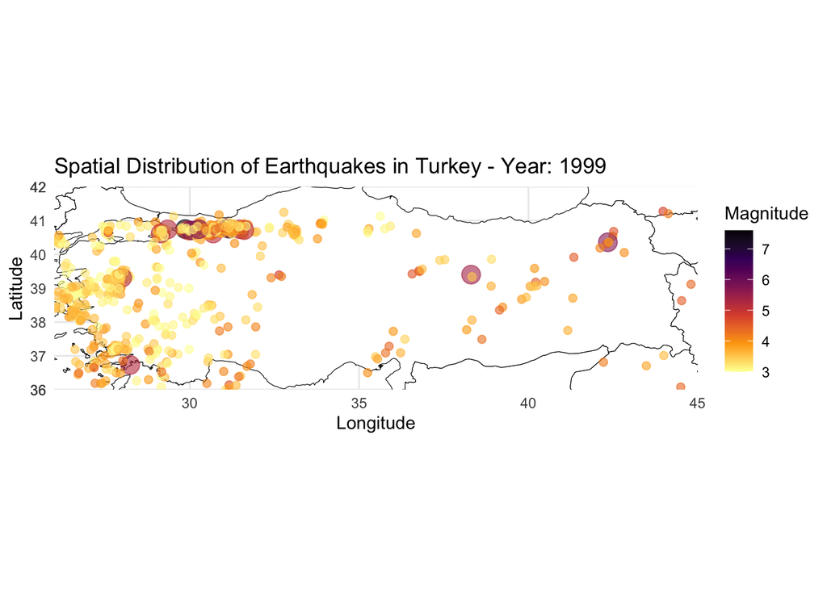

```
### Earthquake Distribution for Year: 2023
```

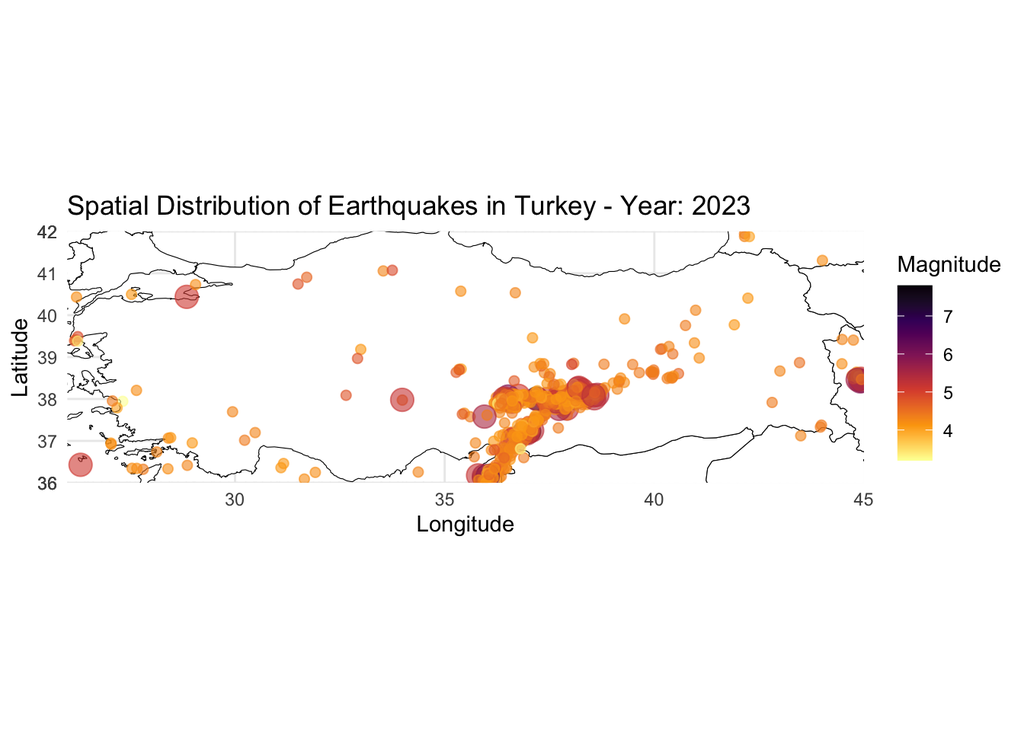

```
### Earthquake Distribution for Year: 2004
```

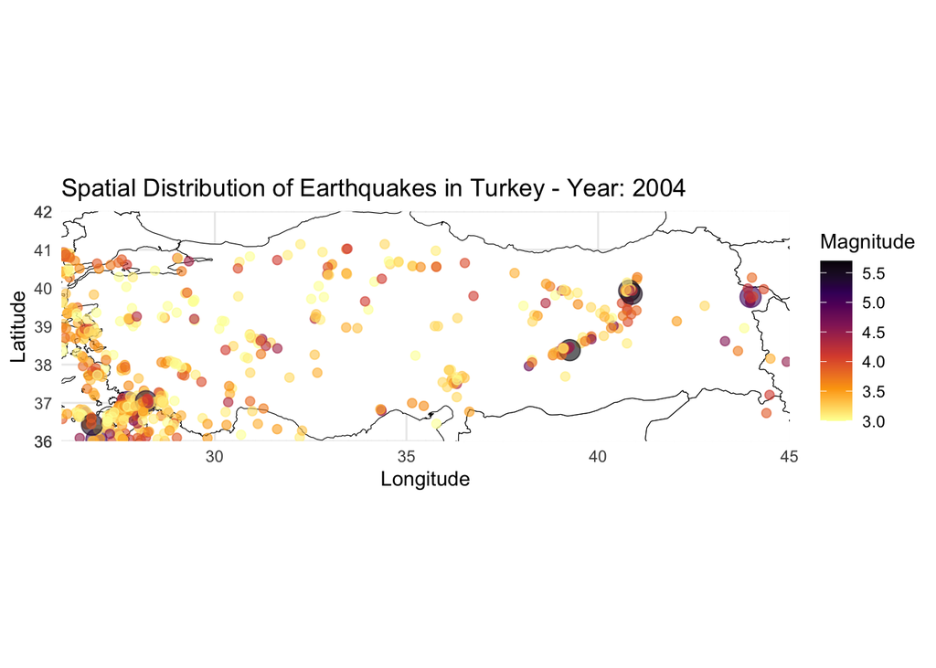

```
### Earthquake Distribution for Year: 1993
```

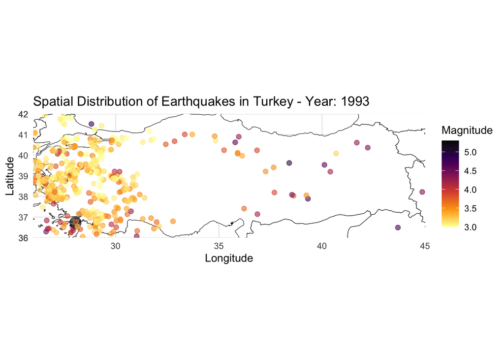

```
### Earthquake Distribution for Year: 2007
```

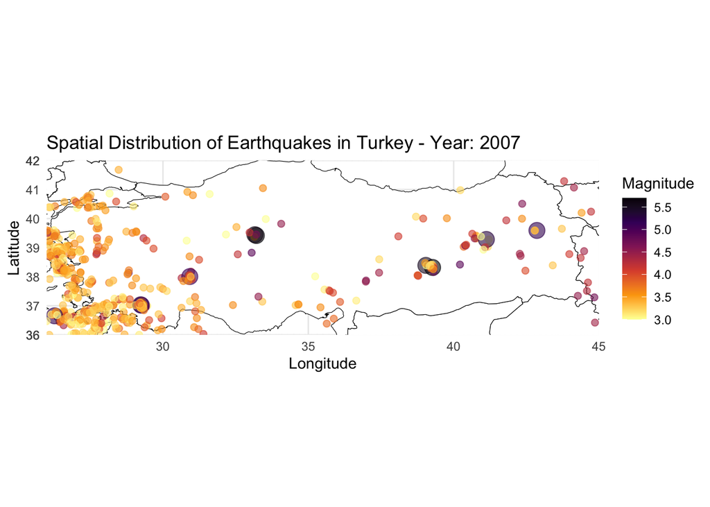

```
### Earthquake Distribution for Year: 2006
```

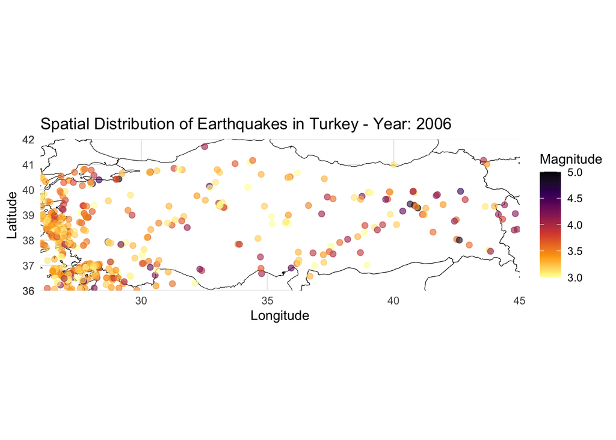

```
### Earthquake Distribution for Year: 1991
```

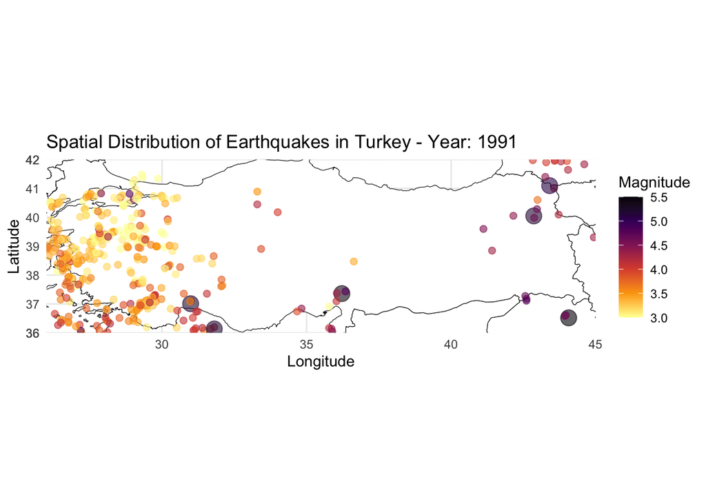

```
### Earthquake Distribution for Year: 1995
```

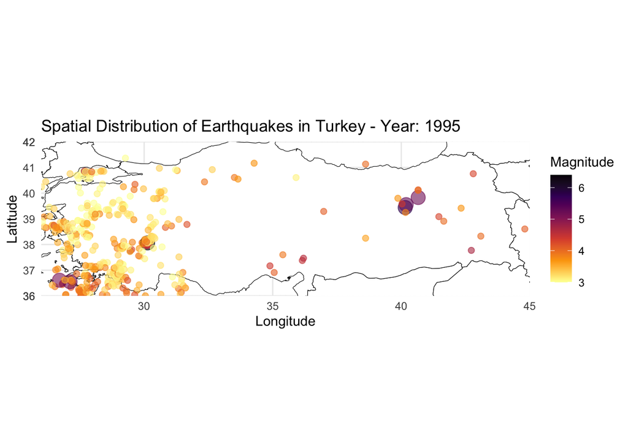

```r
library(ggplot2)
library(sf)

turkey_shapefile <- st_read("/Users/akbulut/Documents/GitHub/emu660-spring2025-edagrlk/turkey.shp")
top10_years <- names(sort(table(eq_data$year), decreasing = TRUE))[1:10]

for (yr in top10_years) {
  eq_year <- subset(eq_data, year == yr)

  cat("\n\n### Earthquake Distribution for Year:", yr, "\n\n")

  print(
    ggplot() +
      geom_sf(data = turkey_shapefile, fill = "white", color = "black") +
      geom_point(data = eq_year,
                 aes(x = longitude, y = latitude, color = mag),
                 alpha = 0.6,
                 size = ifelse(eq_year$mag > 5, 5, 2)) +  # 5'ten büyükse 5, değilse 2
      scale_color_viridis_c(option = "inferno", direction = -1) +
      coord_sf(xlim = c(26, 45), ylim = c(36, 42), expand = FALSE) +
      labs(title = paste("Spatial Distribution of Earthquakes in Turkey - Year:", yr),
           x = "Longitude", y = "Latitude", color = "Magnitude") +
      theme_minimal()
  )
}
```

The earthquake dataset used in this study reliably captures the spatial and temporal distribution of seismic events across Turkey, including some of the country’s most significant and devastating earthquakes. Notably, large earthquakes such as the 1999 İzmit earthquake, the 2023 Kahramanmaraş earthquake, the 1995 Dinar earthquake, and the 2005 Bingöl earthquake are clearly represented with corresponding high-magnitude events and dense epicenter clusters in the respective years.

This realistic portrayal strengthens the credibility of the data, as it aligns well with well-documented seismic history and major catastrophe timelines. Such consistency supports the use of this dataset for both analytical insights and risk assessment applications.

Regarding human and economic impacts, the following major earthquakes have been associated with severe consequences in terms of fatalities and structural damage:

[output not shown]

Note: The death tolls and damage estimates vary between sources but consistently highlight the catastrophic nature of these events. Note: In 1994, an earthquake occurred in the Marmara region of Turkey. Although it was a noticeable seismic event, it did not result in significant destruction or a high number of casualties compared to other major earthquakes in the country. Therefore, its impact is considered minor relative to catastrophic events such as those in 1999 and 2023.

By comparing our earthquake data with well-known seismic events in Turkey, we were able to confirm that the dataset accurately captures both the timing and strength of the country’s major earthquakes. This allows us to confidently use it as a basis for spatial and temporal analyses as well as for informing risk mitigation strategies.

# 4. Results and Key Takeaways

When we looked at earthquakes in Turkey between 1975 and 2023, we wanted to understand not just how often they happened but also where they were most intense. By combining the time and place of these events, we uncovered patterns that show which years were particularly active and which regions faced the most powerful shakes. These findings help us get a clearer picture of earthquake risks in Turkey and can guide efforts to better prepare and protect communities.

```
*ChatGPT was utilized in this project.
```